# Coursework Report

*N* removed NAs: 3

*N* removed typo: 1

*N* removed <18: 23

*N* total clean: 123

| Group | *N* | *M*<sub>age</sub> | *M*<sub>rating</sub> |
| --- | --- | --- | --- |
| Control | 58 | 20.8 | 5.44 |
| Experim | 65 | 20.9 | 6.26 |

**Main analysis results**

*t*(121) = -5.68, *p* < .001

[interactive chart not shown]

[figure not shown]

[interactive chart not shown]

# Coursework Report

Analysing Data, Spring 2020

# Methods

## Participants

A total of 150 female participants initially took part in this experiment. After removing all participants under the age of 16 and all incomplete sets of data I was left with 139 participants with mean age of 20.40. The average age of the control condition was 20.29, compared to 20.51 in the experimental condition. We removed participants under 16 as it was agreed that participants under 16 could not effectively give informed consent for their data to be used.

Participants by Condition and Age

| Group | N | % | Mean Age | SD Age | Max Age |
| --- | --- | --- | --- | --- | --- |
| Control | 66 | 47.5 | 20.3 | 2.10 | 24 |
| Experimental | 73 | 52.5 | 20.5 | 2.31 | 26 |

## Design

This experiment is testing whether the “red effect” reported in Elliot et al (2010)<sup>1</sup> is replicable. Elliot et al reported that women perceive ment to be “more attractive and sexually desirable when seen on a red background and in red clothing”. This experiment recreates the first of Elliot et al’s experiments in order to test the validity of the results reported. Participants were shown an image of a moderately attractive man on a plain white or red background. They were then asked to report their perceptions on the mans attractiveness. They were asked 3 questions in order to report their perceived attraction: “How attractive do you think this person is?”,“How pleasant is this person to look at?” and “If I were to meet the person in this picture face to face, I would think he is attractive.” They were asked to rate the answers on a scale from 1 (not at all attractive) to 9 (exteremely attractive) This experiment tests the hypothesis that there will be a difference in ratings of attractiveness when presented with an image with a red or white background. We will use an independent measures t-test to assess the significance of the result.

# Results

After taking the mean of the ratings for each condition, we found that the experimental condition had a higher mean rating of attractiveness.

Average Rating by Condition

| Experimental Condition | Mean Rating |
| --- | --- |
| Control | 5.41 |
| Experimental | 6.28 |

We investigated whether people would rate attractiveness differently depending on the colour background presented to them using an independent measures t-test. The test showed that there was a significant difference in the mean attractiveness rating when presented with a red or white background. (*M*<sub>diff</sub> = -0.87, 95% CI [-1.14, -0.6]*t*(137) = -6.35, *p* = .000000003).

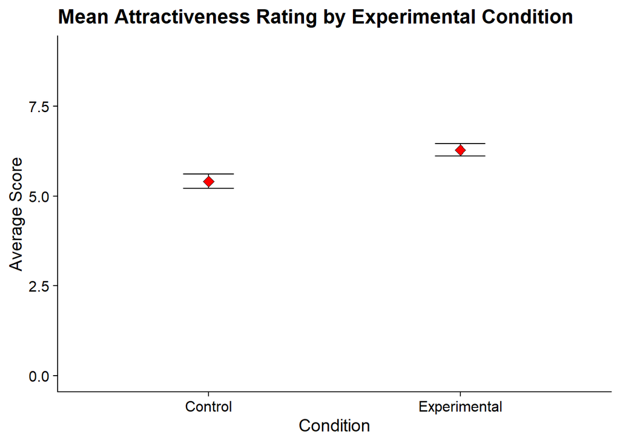

# Discussion

The results of this experiment show that there is a significant increase in attractiveness rating when a red background is presented. This supports the “Red Effect” presented by Elliot et al, that the colour red is associated with attractiveness.

Elliot et al reported a mean perceived attractiveness rating of 6.79 and 5.67 for the experimental and control condition respectively, compared to a rating of 6.28 and 5.41 in our replication. The results of the replication support the reliability of Elliot et al (2010)’s results, and support the red effect presented in the original research. Other replications and variations have produced different results. Hesslinger, Goldbach, & Carbon (2015) conducted a replication study of Elliot et al (2010) using 89 male students. They found a small, non-significant difference between the means of the experimental and control condition (M<sub>red</sub> = 5.71, M<sub>white</sub> = 5.39, t(87) = 0.92, p = 0.360). Peperkoorn, Roberts, & Pollet (2016) conducted a similar study investigating the effect of colour on perceieved attraction. In the first of their studies using a sample of 206 male participants, they found participants rated the white condition to be higher than the red and black condition (on a scale of 1(not at all attractive) to 11(extremely attracive))(M<sub>white</sub> = 7.59, M<sub>red</sub> = 7.06, M<sub>black</sub> = 7.06). The difference was found to be non significant. In their second experiment 191 men and 181 women rated perceived attractiveness in 3 colour conditions (White, Red, Black). No significant difference was found. In their final experiment, 433 men and 436 women were asked to rank perceived sexual receptivity of a woman in 2 colour conditions (White or Red). No significant difference was found between colour conditions.

A possible reason for the contradicting conclusions is that the increased perceived attractiveness may be linked to an increased perceieved status. In Peperkoorn, Roberts & Pollet (2016) the questions asked were to do with perceieved sexual reciprocity or to do with short term or long term relationships. These questions may be less focused towards status, and therefore reduce the difference due to the lack of increased status. There may also be a gender difference as the research conducted on women produced more significant results.

Based on the research previously discussed, as well as my own replication of Elliot et al’s research I am hesitant to say that the “red effect” is a true scientific effect. The amount of contradictory research and variety of methods that point to no significant difference leads me to belive the results found in this study are the exception rather than the rule. Francis (2013) theorises that “the reported experiments were run improperly in a way that inflated the likelihood of rejecting the null hypothesis.” An analysis of the statistics reported found that there was a .005% chance that all 12 findings would reject the null hypothesis. I don’t believe the claim that red makes men seem more attractive due to the large amounts of evidence presented against the case, as well as the publication bias in the original study as discussed by Francis (2013).

Further research into this effect could be a similar replication of Elliot et al (2010) using more valid methodology, ensuring the experiments were run in a way in which the “red effect” can be effectively researched without publication bias.

In conclusion, the replication of Elliot et al’s first experiment into the effect of the colour red on perceieved attractiveness produced a statistically significant result pointing toward the conclusion that colour did influence perceieved attraction. However, due to the large amounts of contradictory research and publication bias reported by Francis (2013) I believe there is no influence, and that the research published by Elliot et al (2010) is invalid.

# References

Elliot, A., Niesta Kayser, D., Greitemeyer, T., Lichtenfeld, S., Gramzow, R., Maier, M. and Liu, H., 2010. Red, rank, and romance in women viewing men. *Journal of Experimental Psychology: General*, 139(3), pp.399-417.

Mankin, J. (2019). *Comparing Two Means: Analysing Data Week 6*[Powerpoint Slides]. University of Sussex. Retrieved from http://users.sussex.ac.uk/~jm636/lecture_6_2means_slides.html#/

Mankin, J. (2019). *Practical 4 - Visualising data: Analysing Data*[Worksheet]. University of Sussex. Retrieved from https://mivalek.github.io/adata/prac/prac_04_wkst.html

Hesslinger, V. M., Goldbach, L., & Carbon, C.-C. (2015). Men in red: A reexamination of the red-attractiveness effect. *Psychonomic Bulletin & Review*, 22(4), 1142–1148.

Peperkoorn, L. S., Roberts, S. C., & Pollet, T. V. (2016). Revisiting the Red Effect on Attractiveness and Sexual Receptivity. *Evolutionary Psychology*, 14(4), 147470491667384.

Francis, G. (2013). Publication bias in “Red, rank, and romance in women viewing men,” by Elliot et al. (2010). *Journal of Experimental Psychology: General*, 142(1), 292–296. doi: 10.1037/a0027923